# Likelihood

PCB 6455 / BSC 4933: Biometry | Lecture 15

Dr. Brian Maitner

## Today’s agenda

- The midterm is due tonight
- Going backwards: from data to parameters
- What likelihood is
- Finding the parameters that maximize it

Type and run on a code block: type it into your script and run it. You will need it later. Code without the label is there to watch.

## The midterm is due tonight

**Tuesday Oct 13, 11:59 pm.** Submit on Canvas, or a Github link on Canvas.

- Part 1 text is yours. Any tools you like for the code.
- Part 3 is Thursday’s power analysis, with the skeleton in `midterm/midterm_b_example.R`.

**Any final questions?**

## Where we are

| Chapter | Question | Direction |
| --- | --- | --- |
| 3 | What shape? |  |
| 4 | What distribution? |  |
| 5 | Given parameters, what data would I see? | parameters $\rightarrow$ data |
| **6** | **Given data, what parameters?** | **data $\rightarrow$ parameters** |

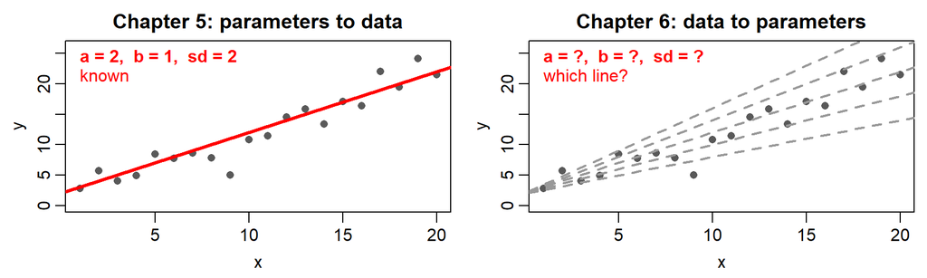

## Why bother estimating parameters?

Because the parameter **is** the biological question:

- **A slope:** how fast is this population declining?
- **A mean:** how many fish does a protected reef hold?
- **A spread:** how variable is egg size between species?
- **A probability:** what fraction of sites are occupied?

A plot shows you the pattern. A parameter lets you **put a number on it, with uncertainty**, and compare it to another number.

## The plan for the next three lectures

1. **Choose a model.** Chapters 3 and 4. *Done.*
2. **Find the parameters that make the data most likely.** *Today.*
3. **Decide which model fits best, and how sure you are.** *Thursday and next week.*

## What is likelihood?

## The probability of your data

**Likelihood** = the probability of getting the data you actually got, if a particular set of parameters were true.

Change the parameters, and that probability changes.

**The maximum likelihood estimate is the parameter value that makes your data least surprising.**

## The same data, two models

**The data:** 71 bird survey routes were run in Florida in 2019. Bobwhite were recorded on **52** of them.

**A model:** every route has the same probability $p$ of holding bobwhite. Below, what that model expects, for two guesses at $p$.

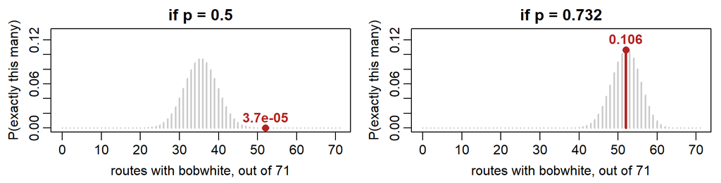

Each grey bar is the probability of **one possible result**, 0 to 71 routes; they add to 1. Red is the result **we got**.

**That red height is the likelihood:** 0.00004 on the left, 0.106 on the right.

## Refresher: the `d` functions give probabilities

From Lecture 12. Every `d` function takes two things: **the data** and **the parameters**.

```r
dbinom(x = 7, size = 10, prob = 0.5)    # P(7 heads in 10 tosses) if p = 0.5
```

```
[1] 0.1171875
```

Which one you hold still decides what you are asking:

```r
dbinom(x = 0:10, size = 10, prob = 0.5)              # parameter fixed, data vary

dbinom(x = 7, size = 10, prob = c(0.3, 0.5, 0.7))    # data fixed, parameter varies
```

The first asks **what results to expect**. The second asks **which parameter best accounts for the result I got**. Your data are already collected and will not change, so the parameter is the thing that moves. That second one is likelihood.

## Get set up

```r
bbs <- read.csv("https://github.com/bmaitner/biometry_course/raw/refs/heads/main/data/BBS/FL_BBS.csv")

# every route surveyed in 2019, and the ones with bobwhite on them
routes_2019 <- length(unique(bbs$Route[bbs$Year == 2019]))

with_bobwhite <- length(unique(bbs$Route[bbs$Year == 2019 &
                       bbs$Scientific_Name == "Colinus virginianus"]))

c(routes = routes_2019, with_bobwhite = with_bobwhite)

# the counts themselves, for the second half of the lecture
bobwhite <- bbs$total_sightings[bbs$Scientific_Name == "Colinus virginianus"]

length(bobwhite)      # 1360 route-years
```

## A question with one parameter

Of **71** Florida routes surveyed in 2019, bobwhite were recorded on **52**.

If each route has the same probability $p$ of holding bobwhite, **what is $p$?**

You already know the answer is 52/71. Good: that means you can check whether likelihood gives the right answer on a problem where you can see it.

## Try one value

If $p$ were 0.5, how likely is 52 out of 71?

```r
dbinom(x = 52, size = 71, prob = 0.5)
```

```
[1] 3.671053e-05
```

Now try `prob = 0.6`, then `0.73`, then `0.8`. Which gives the biggest number?

## Try every value

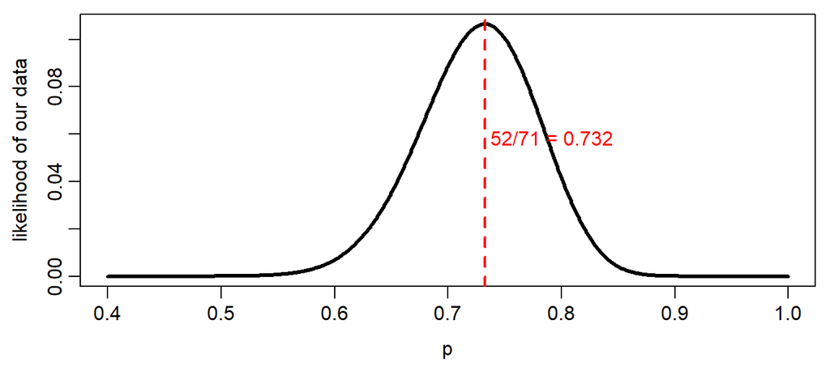

The curve peaks exactly at **52/71 = 0.732**. The machinery agrees with the obvious answer.

## What if you have more than one observation?

So far, one number: 52 out of 71. The bobwhite **counts** are 1360 numbers.

If the observations are independent, the probability of getting **all** of them is each probability **multiplied together**:

```r
dpois(bobwhite[1:5], lambda = 10.8)        # probability of each of the first 5

prod(dpois(bobwhite[1:5], lambda = 10.8))  # all five together

prod(dpois(bobwhite[1:50], lambda = 10.8)) # fifty

prod(dpois(bobwhite, lambda = 10.8))       # all 1360
```

**What happened on that last line?**

## Why we use logs

You just watched the product of 1360 probabilities collapse to zero:

$$L = \prod_i P(y_i \mid \text{parameters})$$

Nothing is wrong with the arithmetic. The number really is that small, and the computer cannot hold it. Taking logs turns multiplication into addition:

$$\log L = \sum_i \log P(y_i \mid \text{parameters})$$

By convention we minimize the **negative** log-likelihood, because optimizers minimize.

## Why the optimizer prefers the log

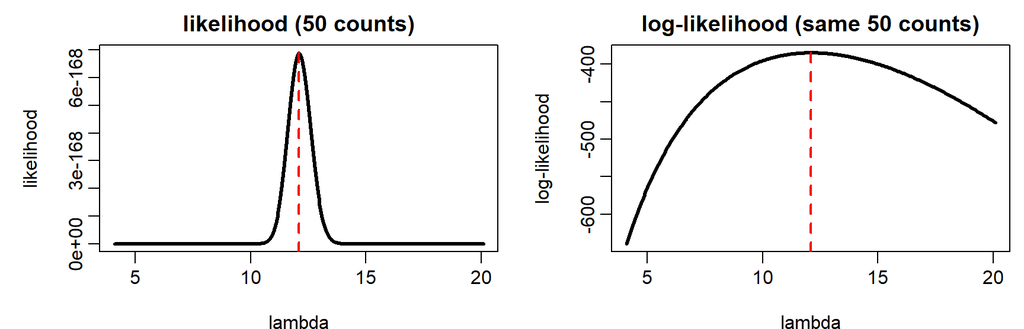

Same data, same peak (red). On the left the curve is flat at zero almost everywhere; on the right there is a slope to follow from anywhere.

## A refresher on writing functions

From Lecture 9: name, arguments, body, and the last line is the result.

```r
standard_error <- function(x){
  sd(x) / sqrt(length(x))
}
```

To use an optimizer, you hand it a function to minimize. So we write one that takes a parameter and returns a negative log-likelihood:

```r
nll_name <- function(parameter){
  -sum(dsomething(data, parameter, log = TRUE))
}
```

## The negative log-likelihood, for real

```r
binom_nll <- function(p){
  -dbinom(x = with_bobwhite, size = routes_2019, prob = p, log = TRUE)
}

binom_nll(0.5)
```

```
[1] 10.21245
```

```r
binom_nll(0.732)
```

```
[1] 2.240282
```

Smaller is better: the second is the one that makes our data less surprising.

## Let R find the minimum

```r
fit <- optimize(binom_nll, interval = c(0, 1))

fit$minimum       # the estimate
```

```
[1] 0.7323749
```

```r
fit$objective     # the negative log-likelihood there
```

```
[1] 2.240254
```

`optimize()` for one parameter, `optim()` for several.

## Two parameters: back to the counts

## Thursday’s unfinished business

On Thursday we needed a negative binomial for the bobwhite counts, and got its clumping parameter by **matching the variance**:

```r
mu_moment <- mean(bobwhite)
size_moment <- mu_moment^2 / (var(bobwhite) - mu_moment)

round(c(mu = mu_moment, size = size_moment), 3)
```

```
    mu   size
10.782  1.155
```

That was a shortcut. **Maximum likelihood is the principled version**, and it uses the whole distribution rather than two summaries.

## The likelihood surface

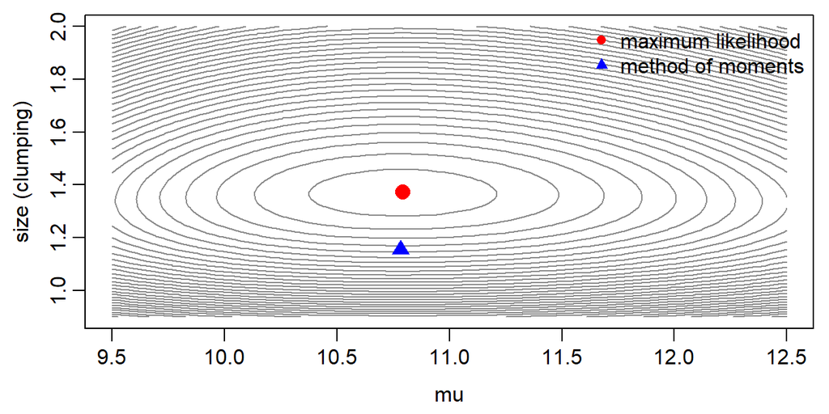

With two parameters the likelihood is a **surface**, and the estimate is its lowest point on the negative log scale.

## Fitting it

```r
nb_nll <- function(mu, size){
  -sum(dnbinom(bobwhite, mu = mu, size = size, log = TRUE))
}

fit_nb <- optim(par = c(mu = 10, size = 1),
                fn = function(p){
                  nb_nll(p["mu"], p["size"])
                },
                method = "BFGS")

round(fit_nb$par, 3)
```

```
    mu   size
10.786  1.368
```

|  | mu | size |
| --- | --- | --- |
| method of moments | 10.78 | **1.155** |
| maximum likelihood | 10.79 | **1.368** |

## The same fit, with `mle2`

Bolker’s package wraps the same idea in a friendlier interface. **Do the two routes agree?**

```r
library(bbmle)

m1 <- mle2(minuslogl = nb_nll,
           start = list(mu = 10, size = 1),
           data = list(bobwhite = bobwhite))

coef(m1)

coef(m1) - fit_nb$par        # should be about zero
```

## Remember why we rejected the Poisson

On Thursday we tested it against these same counts:

|  | observed | Poisson said |
| --- | --- | --- |
| variance | 111 | 11 |
| P(count $\geq$ 40) | 0.024 | 0.000000000007 |

We threw it out on those two rows. **Likelihood lets us put one number on how much worse it was.**

## Was the negative binomial worth it?

A Poisson has one parameter, and its best value is just the mean, so there is nothing to optimize:

```r
nll_poisson <- -sum(dpois(bobwhite, lambda = mean(bobwhite), log = TRUE))
nll_negbin <- fit_nb$value

round(c(poisson = nll_poisson, negative_binomial = nll_negbin))
```

```
          poisson negative_binomial
             8455              4627
```

The negative binomial is **thousands** of log-likelihood units better.

How much better is “better enough”? **That is next week.**

## Your turn: estimate the decline

Thursday we **assumed** a 3% decline. Now estimate it from the counts:

```r
bob <- bbs[bbs$Scientific_Name == "Colinus virginianus", ]
counts <- bob$total_sightings
year <- bob$Year - min(bob$Year)        # 0, 1, 2, ... 23

trend_nll <- function(mu0, decline, size){
  mu <- mu0 * (1 - decline)^year        # the mean declines each year
  # your negative log-likelihood goes here
  # (hint: you wrote one for these counts a few slides ago)
}

fit_trend <- optim(par = c(mu0 = 15, decline = 0.03, size = 1),
                   fn = function(p){
                     # call your NLL function here, with the three parameters
                   },
                   method = "L-BFGS-B",
                   lower = c(0.1, -0.5, 0.05),
                   upper = c(100, 0.5, 50))

fit_trend$par
```

**What annual decline did you get? Compare it to the 3% we assumed.**

## Your turn: a different species

```r
# pick a species, any species

counts <- bbs$total_sightings[bbs$Scientific_Name == "____"]

mean(counts)
var(counts) / mean(counts)        # still clumped?

nb_nll2 <- function(mu, size){
  -sum(dnbinom(counts, mu = mu, size = size, log = TRUE))
}

optim(par = c(mu = mean(counts), size = 1),
      fn = function(p){

        # call your NLL function here, with the two parameters

      },
      method = "BFGS")$par
```

How does the fitted `size` compare with the moment estimate, `mean(counts)^2 / (var(counts) - mean(counts))`?

## What you can now do

- Write down the probability of your data under a model
- Turn it into a negative log-likelihood
- Hand that to an optimizer and get **estimates from real data**

Still missing: parameters that **depend on something else**. That is Thursday.

## Before next class

Read Bolker **6.3** (6.3.2 optional)

Next time: fitting a model where the parameter **changes with a covariate**, as the decline exercise just did